# 6 Distributions de probabilités

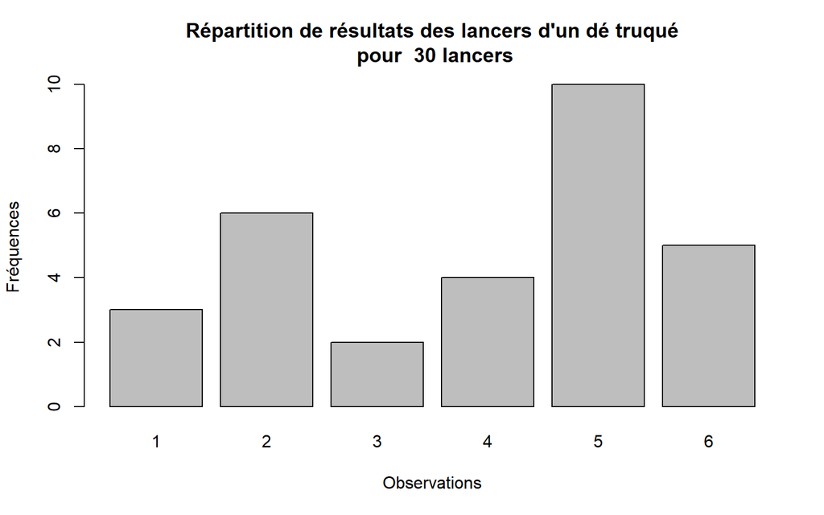

```r
No_essais = 30
p6 = sample(c(rep(1.6667, 5), 1.6667 + runif(1, -0.7, 0.7)),6)
res = DiceRoll(No_essais, p = p6)
    Freq = as.matrix(table(res))
    Prop <- Freq / sum(Freq)
    Faces <- sort(unique(res))
    ft = data.frame(Faces, Freq, Prop)
titl = paste("Répartition de résultats des lancers d'un dé truqué\n pour ",
    No_essais, "lancers")
barplot(height = ft$Freq, names = ft$Face, xlab = "Observations",
    ylab = "Fréquences", main = titl)
```

6. Êtes-vous en mesure de conclure sans doute raisonnable que le dé a été trafiqué, sur la base de ces données?
- Solution:
  - Les probabilités semblent différer pour les différentes faces du dé. Mais le nombre d’essais est trop faible pour permettre une conclusion définitive…
7. Répétez l’expérience en modifiant le nombre d’essais graduellement: 60, 120, 300, 1,000, 3,000… À partir de quel moment auriez-vous confiance en affirmant que le dé est truqué, sur la base des observations?
- Solution:
  - Le code R est modifié afin de permettre la simulation impliquant différents nombres d’essais. Au besoin, vous pouvez ajouter des nombres d’essais au départ de la boucle **for()**:

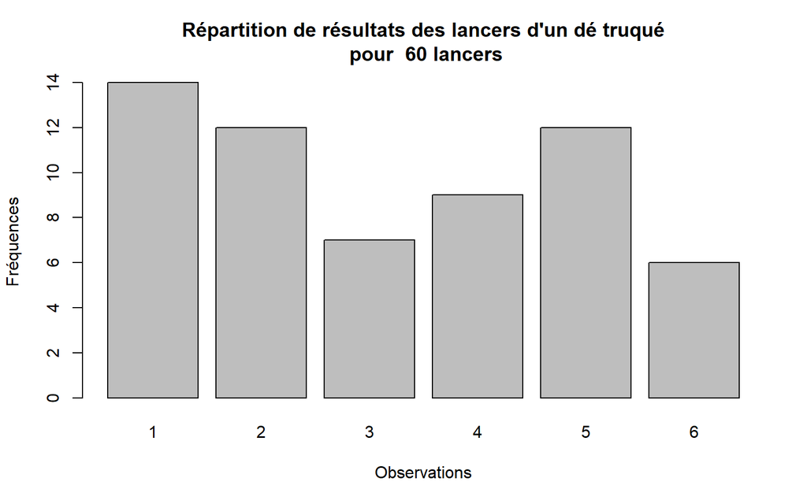

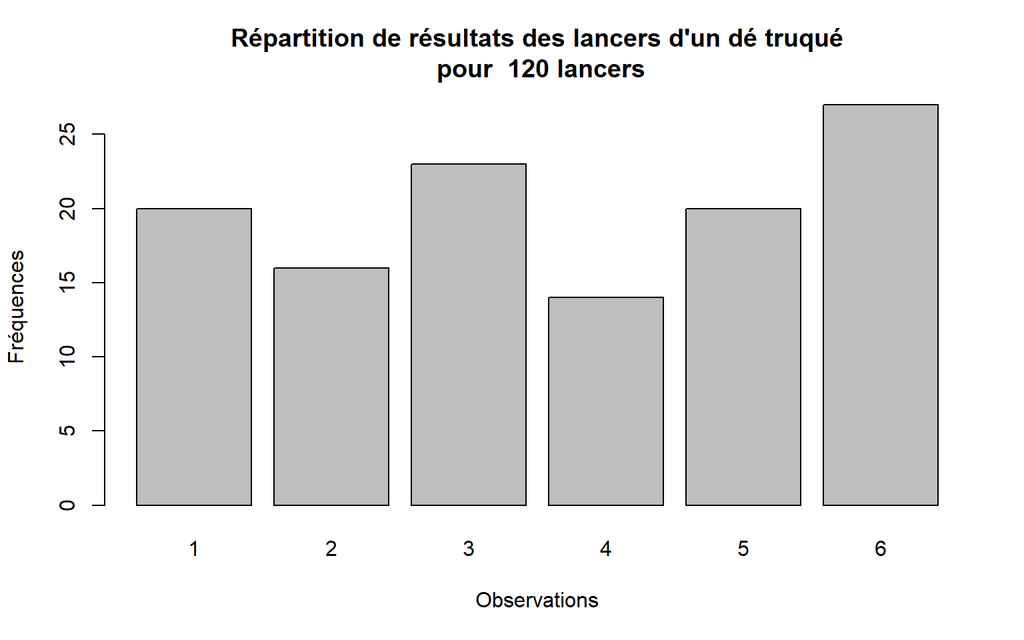

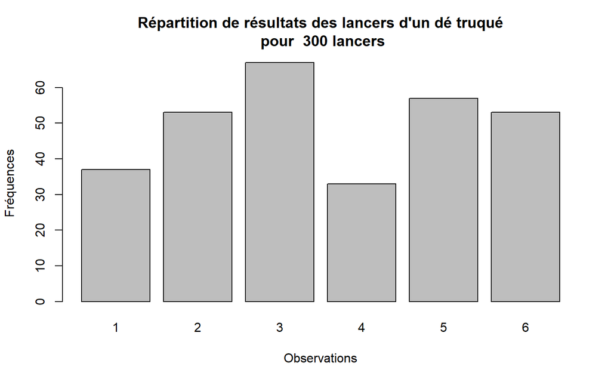

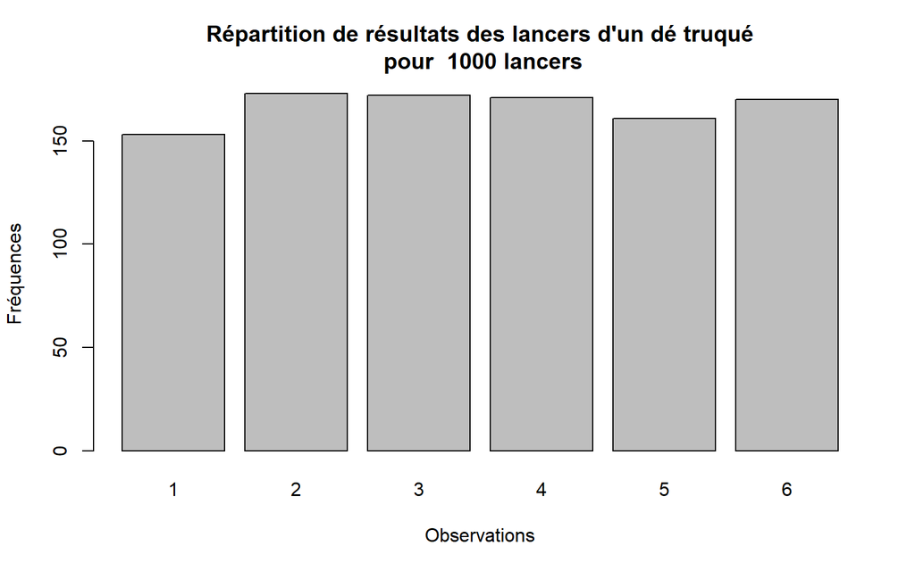

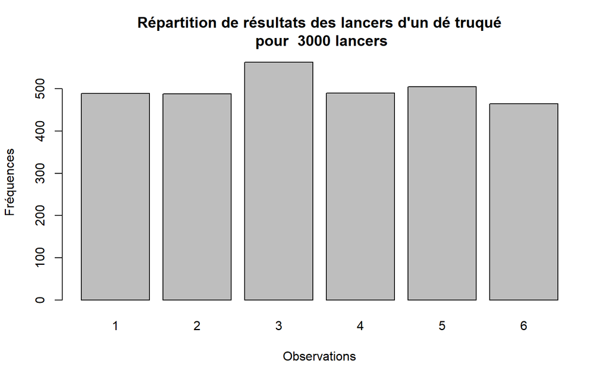

```r
p6 = sample(c(rep(1.6667, 5), 1.6667 + runif(1, -0.7, 0.7)),6)
res=vector()
for(No_essais in c(60,120,300,1000,3000)){
  res = DiceRoll(No_essais, p = p6)
    Freq = as.matrix(table(res))
    Prop <- Freq / sum(Freq)
    Faces <- sort(unique(res))
    ft = data.frame(Faces, Freq, Prop)
  titl = paste("Répartition de résultats des lancers d'un dé truqué\n pour ",
               No_essais, "lancers")
  barplot(height = ft$Freq,
          names = ft$Face,
          xlab = "Observations",
          ylab = "Fréquences",
          main = titl)
}
```

8. Pour quelle face le dé est-il trafiqué, et quelle est la probabilité d’obtenir ce résultat, à 5 décimales près? Il est possible que vous deviez utiliser un grand nombre d’essais pour le déterminer… Pour les données actuelles, le vecteur **p6** contient les valeurs:

```r
p6
```

```
#> [1] 1.666700 1.666700 1.973523 1.666700 1.666700 1.666700
```

Ces valeurs sont proportionnelles aux probabilités d’obtenir 1, 2, 3, 4, 5 ou 6, respectivement, en lançant le dé. En relançant l’exercice, vous obtiendrez des résultats différents, la face truquée et les probabilités varieront d’une fois à l’autre. Expérimentez!

### 6.14.7 Exercice 7

1. Pourriez-vous écrire un code R permettant de simuler le lancer de 10 dés non truqués et de calculer la somme des valeurs observées? Inscrivez votre code dans l’espace ci-dessous. Puis appliquez ce code dans la console.
- Solution:
  - Le code R pourrait ressembler à ceci (plusieurs façons existent!)

  ```r
  dice.roll <- sample(1:6, size = 10, replace = TRUE)
  dice.roll
  ```

  ```
  #>  [1] 3 3 1 6 1 5 4 4 3 6
  ```

  ```r
  sum(dice.roll)
  ```

  ```
  #> [1] 36
  ```

2. Pourriez-vous écrire un code R permettant de lancer un seul dé à 20 reprises? Utilisez l’espace ci-dessous pour ce faire, puis appliquez ce code dans la console.
- Solution:
  - Votre code R pourrait ressembler à ceci:

  ```r
  replicate(20,sample(1:6,size=1,replace=TRUE))
  ```

  ```
  #>  [1] 6 3 4 3 6 4 4 2 4 1 5 3 5 4 3 4 3 5 2 4
  ```

### 6.14.8 Exercice 8

Puisque les données varient aléatoirement d’une expérience à l’autre, relançons la simulation nécessaire à cet exercice:

```r
No_essais = 500  # Définition du nombre d'essais
x = replicate(No_essais, two.dice())
ft = as.matrix(table(x))
ft = data.frame(sort(unique(x)), ft, ft/sum(ft))
colnames(ft) = c("Somme", "Fréq", "Prop")
kable(ft, booktabs = TRUE, caption = "Résultats du lancer de 2 dés",
    row.names = FALSE) %>%
    kable_styling(full_width = FALSE)
```

Résultats du lancer de 2 dés

| Somme | Fréq | Prop |
| --- | --- | --- |
| 2 | 11 | 0.022 |
| 3 | 22 | 0.044 |
| 4 | 54 | 0.108 |
| 5 | 56 | 0.112 |
| 6 | 61 | 0.122 |
| 7 | 81 | 0.162 |
| 8 | 79 | 0.158 |
| 9 | 55 | 0.110 |
| 10 | 34 | 0.068 |
| 11 | 32 | 0.064 |
| 12 | 15 | 0.030 |

**Les données à examiner se trouvent dans la variable x**

1. En vous basant sur la dernière distribution obtenue suite à 500 lancers de deux dés, quelle serait la probabilité d’obtenir une somme supérieure à 10?

```r
sum(x>10)/length(x)
```

```
#> [1] 0.094
```

2. Toujours en vous basant sur la distribution obtenue, quelle serait la probabilité d’obtenir une somme supérieure à 10 ou inférieure à 5?

```r
sum((x>10)|(x<5))/length(x)
```

```
#> [1] 0.268
```

3. Quelle serait la probabilité d’obtenir une somme comprise entre 6 et 8?

```r
sum((x<=8)&(x>=6))/length(x)
```

```
#> [1] 0.442
```

4. Quelle est la probabilité d’obtenir au plus une somme égale à 6?

```r
sum(x<=6)/length(x)
```

```
#> [1] 0.408
```

5. Quelle est la probabilité d’obtenir au moins une somme égale à 6?

```r
sum(x>=6)/length(x)
```

```
#> [1] 0.714
```

### 6.14.9 Exercice 9

Relançons la simulation en utilisant 500,000 réplications (si vous avez un peu plus de temps, essayez 1 million de réplications).

```r
No_essais = 500000  # Définition du nombre d'essais
x = replicate(No_essais, two.dice())
ft = as.matrix(table(x))
ft = data.frame(sort(unique(x)), ft, ft/sum(ft))
colnames(ft) = c("Somme", "Fréq", "Prop")
kable(ft, booktabs = TRUE, caption = "Résultats du lancer de deux dés",
    row.names = FALSE) %>%
    kable_styling(full_width = FALSE)
```

Résultats du lancer de deux dés

| Somme | Fréq | Prop |
| --- | --- | --- |
| 2 | 13996 | 0.027992 |
| 3 | 27903 | 0.055806 |
| 4 | 41546 | 0.083092 |
| 5 | 55687 | 0.111374 |
| 6 | 70063 | 0.140126 |
| 7 | 82920 | 0.165840 |
| 8 | 69635 | 0.139270 |
| 9 | 55259 | 0.110518 |
| 10 | 41254 | 0.082508 |
| 11 | 27942 | 0.055884 |
| 12 | 13795 | 0.027590 |

1. Dans cette distribution, quelle est la probabilité d’obtenir une somme supérieure à 10?
- Solution:

```r
sum(x>10)/length(x)
```

```
#> [1] 0.083474
```

2. Quelle serait la probabilité d’obtenir une somme supérieure à 10 ou inférieure à 5?
- Solution:

```r
sum((x>10)|(x<5))/length(x)
```

```
#> [1] 0.250364
```

3. Quelle serait la probabilité d’obtenir une somme comprise entre 6 et 8?
- Solution:

```r
sum((x>=6)&(x<=8))/length(x)
```

```
#> [1] 0.445236
```

4. Quelle est la probabilité d’obtenir une somme inférieure ou égale à 6?
- Solution:

```r
sum(x<=6)/length(x)
```

```
#> [1] 0.41839
```

5. Quelle est la probabilité d’obtenir une somme supérieure ou égale à 6?
- Solution:

```r
sum(x>=6)/length(x)
```

```
#> [1] 0.721736
```

6. Comparez ces trois probabilités à celles obtenues dans l’exercice 3. Quel ensemble de probabilités vous semble le plus précis?
- Solution:
  - La simulation impliquant le plus grand nombre de réplications sera toujours le plus précis.
7. Considérez une modification de la fonction two.dice() qui retourne la valeur des deux dés, plutôt que leur somme:

```r
two.dice2 <- function(){
  dice <- sample(1:6, size = 2, replace = TRUE)
  return(dice)
}
```

- En utilisant cette fonction et la fonction replicate(), obtenez la probabilité d’obtenir un double, soit (1,1), (2,2), …, (6,6))?
  - Solution:

  ```r
  nrep = 10000
  x = replicate(nrep,two.dice2())
  cat("La probabilité d'obtenir un double = ",sum(x[1,]==x[2,])/nrep)
  ```

  ```
  #> La probabilité d'obtenir un double =  0.1638
  ```

8. Quelle serait la probabilité qu’au moins un des deux dés soit un ‘6’?
- Solution:

```r
cat("La probabilité d'obtenir au moins un 6 = ",
    sum((x[1,]==6)|(x[2,]==6)|((x[1,]==6)&(x[2,]==6)))/nrep)
```

```
#> La probabilité d'obtenir au moins un 6 =  0.3144
```

9. Il existe un vieux jeu de hasard italien appelé Passadieci, dans lequel le but est d’obtenir au moins 11 lorsque trois dés à six faces sont lancés. La fonction suivante vous permettra d’effectuer autant d’expériences aléatoires (lancers de 3 dés) que vous le désirez et d’obtenir la somme de ces trois dés:

```r
three.dice = function(){
  res = sample(1:6,3,replace = TRUE)
  return(sum(res))
}
```

1. Utilisez cette fonction et la fonction replicate() pour simuler 100,000 réplications de ce jeu et sauvegardez les résultats dans un vecteur appelé passadieci.
- Solution:

```r
passadieci = replicate(100000,three.dice())
```

- Utilisez ce vecteur pour répondre aux questions suivantes :
2. Quelle est la probabilité de gagner à ce jeu (ie obtenir une somme supérieure ou égale à 11) ?

```r
sum(passadieci>=11)/length(passadieci)
```

```
#> [1] 0.49997
```

3. Qu’est-ce qui est le plus probable en lançant trois dés : obtenir 11 ou obtenir 12 ?

```r
s11 = sum(passadieci==11)/length(passadieci)
s12 = sum(passadieci==12)/length(passadieci)
if(s11<s12){cat("Obtenir 12 est plus probable")
}else{cat("Obtenir 11 est plus probable")}
```

```
#> Obtenir 11 est plus probable
```

4. Quelle est la probabilité d’obtenir une somme inférieure ou égale à 7 ou supérieure ou égale à 15, toujours en lançant nos 3 dés?

```r
  sum((passadieci<=7)|(passadieci>=15))/length(passadieci)
```

```
#> [1] 0.25573
```

5. Tracez un graphique pour illustrer l’ensemble de la distribution des probabilités.

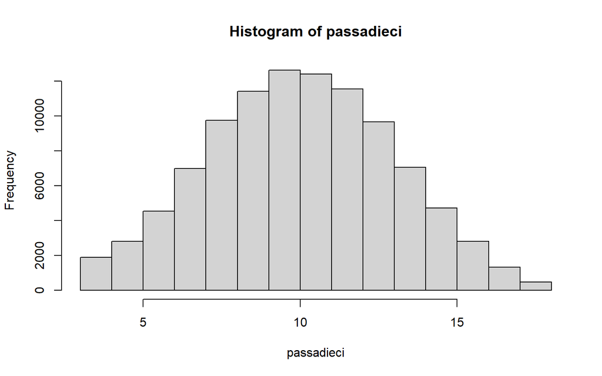

```r
hist(passadieci)
```

10. Parmi les deux situations suivantes, laquelle est la plus probable?
    1. obtenir au moins un 6 en lançant 4 fois un seul dé à six faces.
    2. obtenir au moins une paire de 6 en lançant 24 fois deux dés à six faces.
    - Vous devez donc effectuer deux simulations de manière à déterminer la probabilité d’obtenir au moins un ‘6’ en lançant 4 dés. La fonction suivante pourrait s’avérer utile:

```r
SituationA <- function(){
  rolls <- sample(1:6, size = 4, replace = TRUE)
  res1 <- sum(rolls == 6) > 0
  return(res1)
}
```

- la probabilité d’obtenir au moins une paire de 6 en lançant 24 fois deux dés. La fonction suivante devrait pouvoir faire le travail:

```r
SituationB <- function(){
  d1 <- sample(1:6, size = 24, replace = TRUE)  # Deux dés sont lancés
  d2 <- sample(1:6, size = 24, replace = TRUE)  # 24 fois
  res2 <- sum((d1 == d2) & (d1 == 6)) > 0       # Condition recherchée
  return(res2)
}
```

- Pour répondre à la question, il suffira d’utiliser la fonction **replicate()** pour chacune de ces deux fonctions pour établir la distribution de probabilités correspondant aux deux situations. On pourra alors déterminer laquelle des situations est la plus probable!
- Solution:

```r
x = replicate(10000,SituationA())
p1 = sum(x)/length(x)
y = replicate(10000,SituationB())
p2 = sum(y)/length(y)
cat("Probabilité de la situation A = ",p1)
```

```
#> Probabilité de la situation A =  0.5035
```

```r
cat("Probabilité de la situation B = ",p2)
```

```
#> Probabilité de la situation B =  0.4928
```

```r
if(p1<p2){cat("La situation B est plus probable!")
  }else{cat("La situation A est plus probable!")}
```

```
#> La situation A est plus probable!
```

### 6.14.10 Exercice 10

Pour les exercices suivants, utilisez l’approche classique et la simulation pour obtenir les réponses:

1. Sous le balcon de Juliette, Roméo cueille des fleurs pour lui lancer un bouquet. Le parterre de roses (la fleur) comporte 4 fleurs rouges, 3 fleurs jaunes et 5 fleurs roses. Roméo procédant dans l’obscurité, il ne peut pas contrôler la couleur des fleurs qui est donc considérée comme aléatoire.
1. Si Roméo cueille trois fleurs, quelle est la probabilité qu’il obtienne trois fleurs de couleur rose ?
- Solution:
  - Classique:
    $$nS = \binom{12}{3}=\frac{12!}{3!(12-3)!}=220$$
    $$nE = \binom{5}{3}=\frac{5!}{3!(5-3)!}=10$$
    $$P(3 Roses)=\frac{10}{220}=0.045$$
  - Simulation:
    - Utilisons la fonction PolyUrn(), modifié pour un contexte bucolique:

    ```r
    polyUrn = function(n=20, R=5, j=7, r=10, repl=FALSE){
      # n: size of draws
      # R: Nombre de fleurs rouges
      # j: Nombre de fleurs jaunes
      # r: Nombre de fleurs roses
      urn = c(rep("Rouge", R), rep("Jaune", j), rep("Rose", r))
      draw = sample(urn, size=n, replace=repl)
      x = c(sum(draw=="Rouge"), sum(draw == "Jaune"), sum(draw == "Rose"))
      return(x)
    }
    ```

```r
ndraw=100000  # Nombre d'expériences aléatoires (tirage de balles)
n = 3         # Nombre de fleurs formant le bouquet
R = 4         # Nombre de fleurs rouges
j = 3         # Nombre de fleurs jaunes
r = 5         # Nombre de fleurs roses
E = c(0,0,3)  # Événement recherché (R = 0, j = 0, r = 3)
repl = FALSE
succes = 0    # Initialisation des variables servant au comptage
i = 0         #
repeat{
  draw = polyUrn(n,R,j,r,repl)    # Exécution d'une expérience
  i = i + 1
  if(sum(draw==E)==3){succes=succes+1}    # Est-ce un 'succès'?
  if (i == ndraw){break}                  # Exercice complété?
}
cat("Probabilité = ",succes/ndraw)
```

```
#> Probabilité =  0.04563
```

2. Si Roméo cueille trois fleurs, quelle est la probabilité qu’il obtienne une fleur de chaque couleur ? - Solution:
   - Classique:
     $$nS = 220$$
     $$nE = \binom{4}{1}+\binom{3}{1}+\binom{5}{3}=(3)(4)(5)=60$$
     $$P(E)=\frac{60}{220}=0.273$$
   - Simulation:

   ```r
   ndraw=100000  # Nombre d'expériences aléatoires (tirage de balles)
   n = 3         # Nombre de fleurs formant le bouquet
   R = 4         # Nombre de fleurs rouges
   j = 3         # Nombre de fleurs jaunes
   r = 5         # Nombre de fleurs roses
   E = c(1,1,1)  # Événement recherché (R = 1, j = 1, r = 1)
   repl = FALSE
   succes = 0    # Initialisation des variables servant au comptage
   i = 0         #
   repeat{
     draw = polyUrn(n,R,j,r,repl)    # Exécution d'une expérience
     i = i + 1
     if(sum(draw==E)==3){succes=succes+1}    # Est-ce un 'succès'?
     if (i == ndraw){break}                  # Exercice complété?
   }
   cat("Probabilité = ",succes/ndraw)
   ```

   ```
   #> Probabilité =  0.27196
   ```

3. Si Roméo cueille quatre fleurs, quelle est la probabilité qu’il n’obtienne aucune fleur jaune ?
- Solution:
  - Classique:
    $$nS = \binom{12}{4}=\frac{12!}{4!(12-3)!}=495$$
    $$nE = \binom{9}{4}=126$$
    $$P(E)=\frac{126}{495}=0.255$$
  - Simulation:

  ```r
  ndraw=100000  # Nombre d'expériences aléatoires (tirage de balles)
  n = 4         # Nombre de fleurs formant le bouquet
  R = 4         # Nombre de fleurs rouges
  j = 3         # Nombre de fleurs jaunes
  r = 5         # Nombre de fleurs roses
  E = c(1,0,1)  # Événement recherché (R = 1, j = 1, r = 1)
  repl = FALSE
  succes = 0    # Initialisation des variables servant au comptage
  i = 0         #
  repeat{
    draw = polyUrn(n,R,j,r,repl)    # Exécution d'une expérience
    i = i + 1
    if(draw[2]==0){succes=succes+1}     # Est-ce un 'succès'?
    if (i == ndraw){break}              # Exercice complété?
  }
  cat("Probabilité = ",succes/ndraw)
  ```

  ```
  #> Probabilité =  0.25425
  ```

4. Si Roméo cueille deux fleurs, quelle est la probabilité qu’il obtienne des fleurs de couleurs différentes ?
- Solution:
  - Classique:
    $$nS = \binom{12}{2}=\frac{12!}{2!(12-2)!}=66$$
    $$nE = \binom{4}{1}\times\binom{3}{1}+ \binom{4}{1}\times\binom{5}{1}+\binom{3}{1}\times\binom{5}{1}=47$$
    $$P(E)=\frac{47}{66}=0.712$$
  - Simulation:

  ```r
  ndraw=100000  # Nombre d'expériences aléatoires (tirage de balles)
  n = 2         # Nombre de fleurs formant le bouquet
  R = 4         # Nombre de fleurs rouges
  j = 3         # Nombre de fleurs jaunes
  r = 5         # Nombre de fleurs roses
  E = c(1,0,1)  # Événement recherché (R = 1, j = 1, r = 1)
  repl = FALSE
  succes = 0    # Initialisation des variables servant au comptage
  i = 0         #
  repeat{
    draw = polyUrn(n,R,j,r,repl)    # Exécution d'une expérience
    i = i + 1
    succes=succes+!is.element(2,draw)   # Est-ce un 'succès'?
    if (i == ndraw){break}              # Exercice complété?
  }
  cat("Probabilité = ",succes/ndraw)
  ```

  ```
  #> Probabilité =  0.711
  ```

2. En utilisant la fonction polyUrn() et le code définis plus haut, étudiez une situation dans laquelle l’urne contient 15 balles rouges, 7 balles bleues et 20 balles vertes. Répétez les exercices en variant le nombre d’expériences aléatoires.
1. Quelle est la probabilité, en tirant 10 balles, que cet échantillon soit composé de 3 balles rouges, 4 balles bleues et 3 balles vertes? - Solution:
   - Simulation: Le code R permettant de simuler cette situation est reproduit ci-dessous:

```r
ndraw=100000  # Nombre d'expériences aléatoires (tirage de balles)
n = 10        # Nombre de balles tirées lors d'une expérience
r = 15        # Nombre de balles rouges
b = 7         # Nombre de balles bleues
g = 20        # Nombre de balles vertes
E = c(3,4,3)  # Événement recherché (r = 3, b = 4, g = 3)
repl = FALSE
succes = 0    # Initialisation des variables servant au comptage
i = 0         #
repeat{
  draw = polyUrn(n,r,b,g,repl)    # Exécution d'une expérience
  i = i + 1
  if(sum(draw==E)==3){succes=succes+1}    # Est-ce un 'succès'?
  if (i == ndraw){break}                  # Exercice complété?
}
cat("Probabilité = ",succes/ndraw)
```

```
#> Probabilité =  0.01196
```

[output not shown]

```r
nS = choose(42,10)
cat("nS = ",nS)
```

```
#> nS =  1471442973
```

[output not shown]

```r
nE = choose(15,3)*choose(7,4)*choose(20,3)
cat("nE = ",nE)
```

```
#> nE =  18154500
```

```r
cat("P(E) = nE/nS =",nE/nS)
```

```
#> P(E) = nE/nS = 0.01233789
```

2. Quelle est la probabilité, en tirant 10 balles, que cet échantillon soit composé de 2 balles rouges, d’aucune balle bleue et d2 8 balles vertes?
   - Solution:
   - Simulation: Le code R permettant de simuler cette situation est reproduit ci-dessous:

```r
ndraw=100000  # Nombre d'expériences aléatoires (tirage de balles)
n = 10        # Nombre de balles tirées lors d'une expérience
r = 15        # Nombre de balles rouges
b = 7         # Nombre de balles bleues
g = 20        # Nombre de balles vertes
E = c(2,0,8)  # Événement recherché (r = 8, b = 2, g = 0)
repl = FALSE
succes = 0    # Initialisation des variables servant au comptage
i = 0         #
repeat{
  draw = polyUrn(n,r,b,g,repl)    # Exécution d'une expérience
  i = i + 1
  if(sum(draw==E)==3){succes=succes+1}    # Est-ce un 'succès'?
  if (i == ndraw){break}                  # Exercice complété?
}
cat("Probabilité = ",succes/ndraw)
```

```
#> Probabilité =  0.00899
```

[output not shown]

```r
nS = choose(42,10)
cat("nS = ",nS)
```

```
#> nS =  1471442973
```

[output not shown]

```r
nE = choose(15,2)*choose(20,8)
cat("nE = ",nE)
```

```
#> nE =  13226850
```

```r
cat("P(E) = nE/nS =",nE/nS)
```

```
#> P(E) = nE/nS = 0.008989033
```

[output not shown]

3. Quelle est la probabilité qu’un échantillon de 12 balles ne soit composé que de balles vertes?
   - Solution:
   - Simulation: Le code R permettant de simuler cette situation est reproduit ci-dessous:

```r
ndraw=100000  # Nombre d'expériences aléatoires (tirage de balles)
n = 12        # Nombre de balles tirées lors d'une expérience
r = 15        # Nombre de balles rouges
b = 7         # Nombre de balles bleues
g = 20        # Nombre de balles vertes
E = c(0,0,12)  # Événement recherché (r = 8, b = 2, g = 0)
repl = FALSE
succes = 0    # Initialisation des variables servant au comptage
i = 0         #
repeat{
  draw = polyUrn(n,r,b,g,repl)    # Exécution d'une expérience
  i = i + 1
  if(sum(draw==E)==3){succes=succes+1}    # Est-ce un 'succès'?
  if (i == ndraw){break}                  # Exercice complété?
}
cat("Probabilité = ",succes/ndraw)
```

```
#> Probabilité =  0
```

[output not shown]

```r
nS = choose(42,12)
cat("nS = ",nS)
```

```
#> nS =  11058116888
```

[output not shown]

```r
nE = choose(20,12)
cat("nE = ",nE)
```

```
#> nE =  125970
```

```r
cat("P(E) = nE/nS =",nE/nS)
```

```
#> P(E) = nE/nS = 0.00001139163
```

## 6.15 Appendice: Fonctions R

Listing 6.1: DiceRoll()

```sql
#' Dice Roll
#'
#'@param n number of Dice to roll (integer value, default = 1)
#'@param p vector of probabilities of a 'success' (6 probs), default = 6X(1/6)
#'       if it is a single value, the probabilities are equals
#'@return Value of each die
#'@export
DiceRoll <- function(n = 1, p = rep(1, 6)) {
    if (!testInt(n)) {
        stop("n must be an integer!")
    }
    if (length(p) == 1) {
        p <- rep(p, 6)
    }
    if (!is.numeric(p)) {
        stop("p must be between numeric!")
    }
    x <- sample(1:6, n, p, replace = TRUE)
    return(x)
}
```

Listing 6.2: polyUrn()

```sql
#' Urn
#'
#'@param n number of balls to draw from urn (integer value, default = 20)
#'@param r number of RED balls in urn (default = 5)
#'@param b number of BLUE balls in urn (default = 7)
#'@param g number of GREEN balls in urn (default = 10)
#'@param repl: with replacement (TRUE/FALSE)
#'@return vector of 3 elements: numbers of balls drawn from each color
#'@export
polyUrn <- function(n = 20, r = 5, b = 7, g = 10, repl = FALSE) {
    if (!testInt(n)) {
        stop("n must be an integer!")
    }
    if (!testInt(r)) {
        stop("r must be an integer!")
    }
    if (!testInt(b)) {
        stop("b must be an integer!")
    }
    if (!testInt(g)) {
        stop("g must be an integer!")
    }
    if (n > (r + b + g)) {
        stop("Trying to draw more balls that urn content!")
    }
    urn <- c(rep("R", r), rep("B", b), rep("G", g))
    draw <- sample(urn, size = n, replace = repl)
    x <- c(sum(draw == "R"), sum(draw == "B"), sum(draw == "G"))
    return(x)
}
```

Listing 6.3: CoinToss()

```sql
#' Tossing a coin
#'
#'@param n number of coins to toss (integer value, default = 1)
#'@param p probability of a 'success' (Tail/Head), default = 0.5
#'@return either 'Pile' or 'Face'
#'@export
CoinToss <- function(n = 1, p = 0.5) {
    if (!testInt(n)) {
        stop("n must be an integer!")
    }
    if (p < 0 | p > 1) {
        stop("p must be between 0 and 1!")
    }
    coin <- c("Pile", "Face")
    x <- sample(coin, n, c(p, 1 - p), replace = TRUE)
    return(x)
}
```

Listing 6.4: testInt()

```sql
#'
#' Verify that x is an integer value
#'
#'@param x integer value to check: Must be numeric
#'@return TRUE if integer, FALSE if not
#'@export
testInt <- function(x) {
    if (!is.numeric(x)) {
        stop("Argument must be numeric")
    }
    t <- all.equal(x, as.integer(x))
    if (t == TRUE) {
        return(TRUE)
    } else {
        return(FALSE)
    }
}
```